# HW 2: Запуск успешного проекта и факторы, влияющие на это

Чеснокова Елена, eyuchesnokova

## Задача

На основе данных постараться выяснить, какие факторы влияют на то, соберёт проект деньги или нет, какая категория более успешная, как влияет наличие спонсоров на успешность проекта и имеет ли значение, какой период сбора средств у проекта.

### Вопросы

**Вопрос:** Влияет ли наличие спонсоров на успешность проекта?

**Гипотеза:** H0: Между успешнстью проекта и количеством спонсоров не обнаружится значимой связи H1: Между успешностью проекта и количеством спонсоров обнаружится значимая связь.

| t | df | pvalue |
| --- | --- | --- |
| 35.818 | 18474 | 0 |

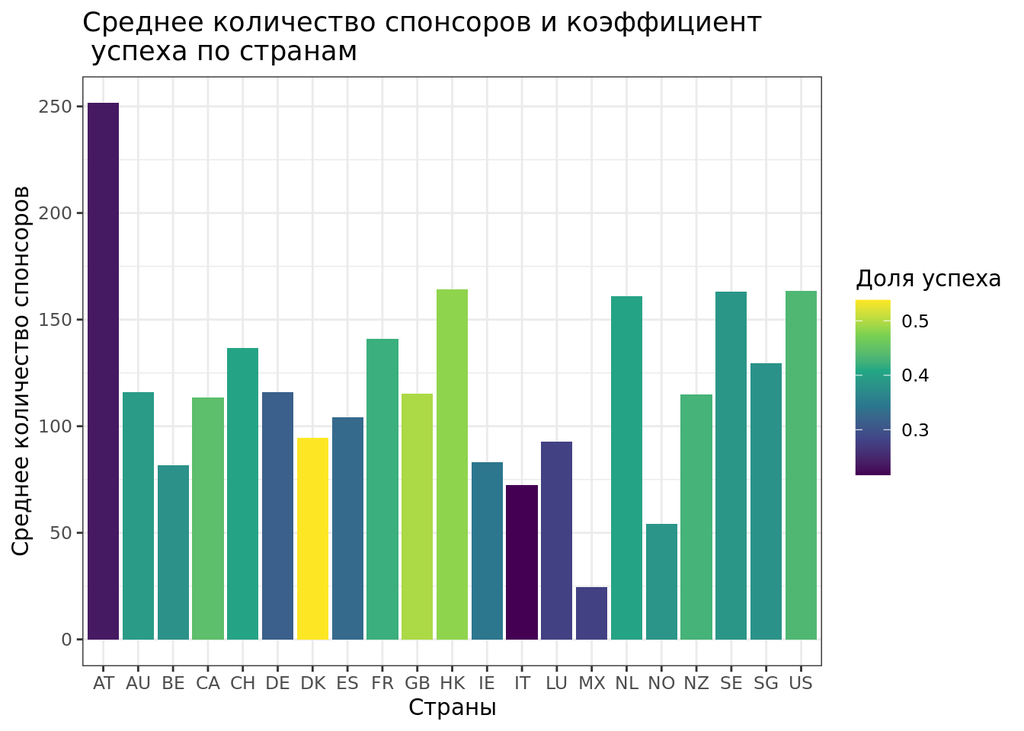

Согласно результатам t-критерия, мы можем опровергнуть нулевую гипотезу, то есть подтвердить связь между количеством спонсоров и успешностью проекта. Такой вывод был сделан исходя из того, что p-value меньше 5%, что говорит нам о неслучайности значений. Также на графике представлены эти два показателя по странам. В каждой стране разные условия для запуска проекта, поэтому имеет смысл это выделить, чтобы посмотреть в каких странах наблюдается эта связь, а в каких - нет. Согласно полученному графику можно сделать вывод, что не всегда большое количество спонсоров означает, что проект соберёт нужную сумму как например, в Австрии. В этой стране наблюдается привлечение большого числа спонсоров (250), однако доля успешных проектов состовляет только 0.23. Более того, не обязательно малое количество полученных от третьих лиц денег ведёт к успеху проекта. Такую ситуацию можно увидеть в Дании, где процент успешности проекта составляет 54%, а среднее количество спонсоров составляет около 90. Из полученных данных следует, что наличие спонсоров влияет на то, соберёт ли деньги проект, однако это не единственный фактор.

**Вопрос:** Какая категория является наиболее успешной для запуска проекта?

**Гипотеза:** H0: Разница в распределении основных категорий по успешности не обнаружится. H1: Обнаружится связь между успешностью проекта и типами категорий.

| X_squared | df | pvalue |
| --- | --- | --- |
| 2331 | 14 | 0 |

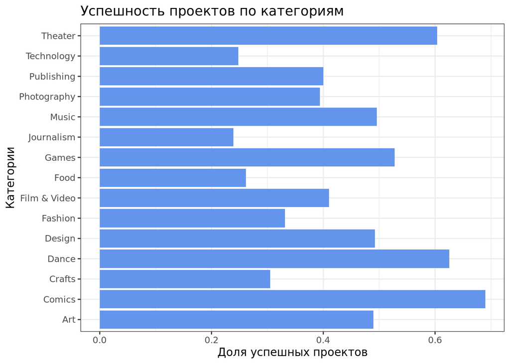

Исходя из полученных данных, можно прийти к выводу, что самыми успешными категориями являются Comics, Theater и Dance. В таких категориях как Journalism, Technology и Food проекты чаще всего не собирают деньги. Помимо того, что бы учитывать долю успешных проектов, нужно учесть общее количество проектов в конкретной категории. Например,в типе Dance высокий коэффициент успеха, но число проектов в этой категории довольно мало, поэтому нельзя сказать, что предпринимателя ждёт больше успеха здесь, чем в Games, хотя там доля успешных проектов ниже. Соответственно, мы получили те типы категорий, которые могут привести к успеху проекта, и это поможет предпринимателям сделать правильный выбор отрасли, в которой запустить проект. То есть, связь между успехом проекта и выбором основной категории подтверждена. Также, согласно результатам теста хи-квадрат, опровергаем нулевую гипотезу и заключаем, что и здесь есть связь между успешностью проекта и типом категории. Это означает, что при запуске стартапа нужно тщательно продумать, какую область выбрать, так как это может повлиять на то, соберёт он деньги или нет.

**Вопрос:** Влияет ли период сбора средств на состояние проекта?

**Гипотеза:** H0: Не обнаружена значимая связь между успешностью проекта и периодом сбора средств Теперь рассмотрим взаимосвязь успешности проекта с периодом времени, за который должен произойти сбор средств. H1: Найдена зачимая взаимосвязь между состоянием проекта и периодом сбора средств.

| t | df | pvalue |
| --- | --- | --- |
| 33.563 | 42772 | 0 |

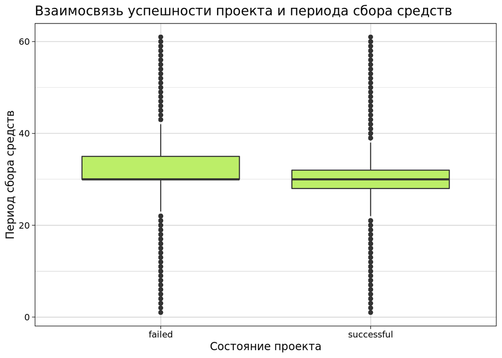

Далее исследуем остальные факторы, которые могут повлиять на состояние проекта. Например, для каждого проекта был рассчитан период времени, за который он должен собрать необходимую сумму. С помощью t-критерия была проверена связь между этим показателем и успешностью проекта. В ходе анализа оказалось, что взаимосвязь значима, так как p-value меньше, чем 0.05. Также, воспользовавшись тестом хи-квадрат и t-критерием, я изучила наличие связи таких показателей как currency, country, usd_goal_real с тем, соберёт ли проект денюги или нет. Исходя мз полученных данных, можно сделать вывод, что между состоянием проекта и конкретным показателем, который был изучён, есть значимая связь, так как p-value и здесь меньше, чем 0.05.

| factor | t | X_squared | df | pvalue |
| --- | --- | --- | --- | --- |
| currency |  | 416.5 | 12 | 0 |
| country |  | 505.73 | 20 | 0 |
| usd_goal_real | 5.6083 |  | 24918 | 0 |

### Построение дерева

Для построения дерева нужно изучить, какие переменные нам подойдут лучше всего, чтобы модель вышла качественной и точной. Для начала посчитаем точность дерева, построенного по всем переменным. Эта величина достигает 99%, а на тестовой выборке - 90%. Несмотря на то, что точнсть показывает хорошие результаты, нельзя не заметить, что дерево учитывает только две переменные: спонсоры и деньги, которые должны быть собраны к назначенному времени. Начинающему предпринимателю принесёт не много пользы такое дерево, так как согласно ему успешность проекта зависит только от спонсоров и бюджета, который нужно собрать, таким образом принятие решение зависит только от суммы денег. Не сложно заметить, что такая модель является не совсем объективной.

Попробуем изменить показатель cp (процент ошибки) на оптимальный. Значение, которое в итоге мы получаем, находится с помощью просмотра графмка и таблицы данного показателя. Проанализиров эти объекты, оптимальным оказалось значение cp = 0.00128517. Построив дерево с этим значением, нельзя не заметить, что в нём сложно разобраться. Соответственно, предпринимателям это дерево не поможет принять правильное решение касательно запуска успешного проекта.

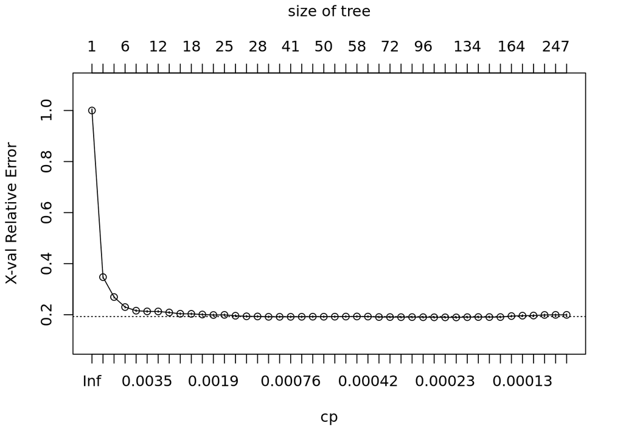

[figure not shown]

Таким образом для того, чтобы построить качественное дерево, вьберем переменные для этого исходя из статистических тестов. Однако нужно учитывать, что тесты показывают наличие значимой связи между двумя конкретными величинами, а не в совокупности. Возьмем те переменные, которые я изучила более тщательно, то есть для которых были построены графики и была найдена связь, а это backers, main_category.

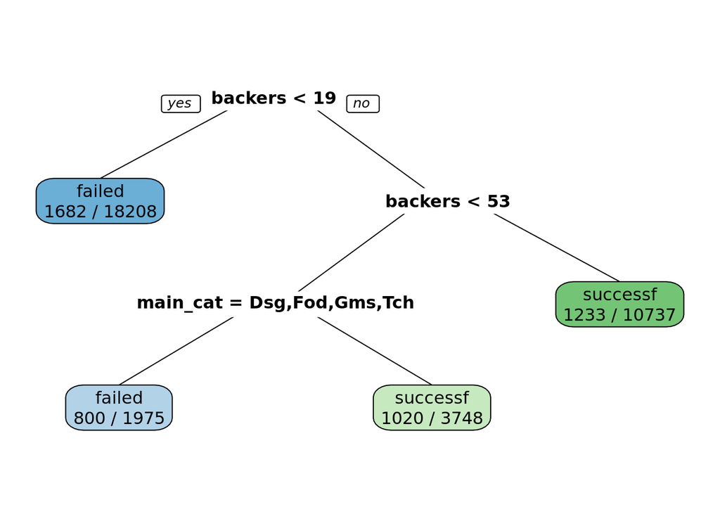

| accuracy_train | accuracy_test |
| --- | --- |
| 0.8634187 | 0.8641975 |

Посчитав точность модели на обучающей и тестовой выборки, можем убедиться, что она примерно равна и там, и там, а это является хорошим показателем, так как значит, что модель не переобучена. В итоге дерево решений составлено по двум переменным, так как именно по ним обнаружена связь с успешностью проекта.